# Racial Disparity in High School Graduation Over Time

The goal of this project is to examine the racial disparity in high school graduation rate for students enrolled in North Carolina public schools over time. I downloaded the data from [NC PDI](https://www.dpi.nc.gov/districts-schools/testing-and-school-accountability/school-accountability-and-reporting/cohort-graduation-rates#4-YearCohortGraduationRates-883).

The formula to calculate the graduation rate is listed as following,

$$\begin{aligned}
high\ school\ graduation\ rate = \frac{Total\ number\ of\
graduates}{Total\ number\ of\ HS\ 12th\ graders}
\end{aligned}$$

Here is a table showing North Carolina graduation rates across racial groups by year.

|  | reporting_year | num_students | graduate_pct | subgroup | num_gradu |
| --- | --- | --- | --- | --- | --- |
| 1 | 2006 | 1449 | 51.1 | AMIN | 740 |
| 2 | 2006 | 2060 | 75.2 | ASIA | 1549 |
| 3 | 2006 | 30565 | 60.4 | BLCK | 18461 |
| 4 | 2006 | 5117 | 52.3 | HISP | 2676 |
| 5 | 2006 | 63993 | 73.5 | WHTE | 47035 |
| 6 | 2007 | 1485 | 55.6 | AMIN | 826 |
| 7 | 2007 | 2183 | 78.9 | ASIA | 1722 |
| 8 | 2007 | 31246 | 61.4 | BLCK | 19185 |
| 9 | 2007 | 5636 | 53.7 | HISP | 3027 |
| 10 | 2007 | 63451 | 75 | WHTE | 47588 |

[output cut: 75 more lines]

I plot a graph to show the graduation rate change over time across racial groups.

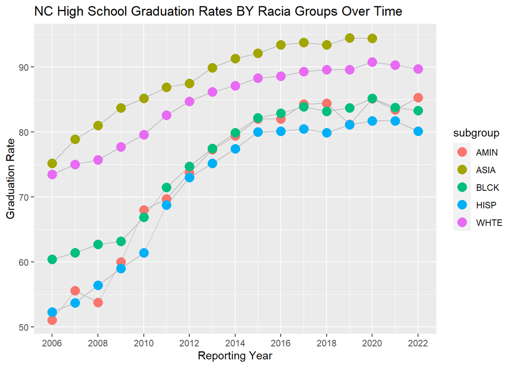

```r
# go to https://github.com/rstudio/cheatsheets/blob/main/data-visualization.pdf
g <- ggplot(data=df.nc.all, aes(x=reporting_year, y=graduate_pct, group=subgroup, color=subgroup))

g + geom_line( color="grey") +
    geom_point(size=4) +
    ggtitle("NC High School Graduation Rates BY Racia Groups Over Time") +
    xlab("Reporting Year") +
    ylab("Graduation Rate") +
    scale_x_continuous(breaks=seq(2006,2022,by=2))
```

## Findings

It clearly shows that the high school graduation rate, for each racial groups, has been **increasing since 2006** in North Carolina.

It is important to note that these graduation rates may vary depending on the specific school or district being considered, as well as other factors such as socioeconomic status and access to resources.

However, overall, Asian and white students tend to have higher graduation rates than African American and Hispanic students.

## Discussion

There are several potential reasons why Asian and white students may have higher graduation rates compared to African American and Hispanic students.

One reason may be that Asian and white students often come from higher socio-economic backgrounds, which can provide them with more resources and support for their education.

Additionally, certain schools or districts may be more geared towards the success of Asian and white students, leading to higher graduation rates among these groups.

There may also be cultural factors at play, such as a greater emphasis on education within certain communities. It is also important to consider that there may be systemic inequalities within the education system that disproportionately impact African American and Hispanic students, leading to lower graduation rates among these groups.

Overall, the reasons for these disparities in graduation rates are complex and multifaceted.